# Forecast

March 18, 2025

```r
suppressMessages(library(viridis))
suppressMessages(library(ramp.work))
#devtools::load_all()
```

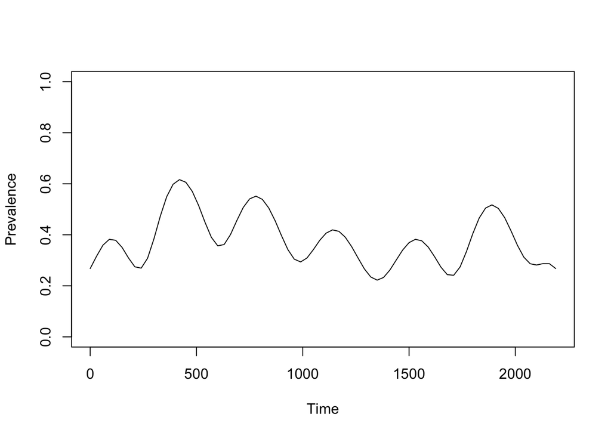

```r
mod1 <- xds_setup_cohort(
  eir = 2/365,
  season_par = makepar_F_sin(bottom=.1),
  trend_par = makepar_F_spline(tt=365*(0:6), yy=c(.7, 2, 1.5, .9, .8, 1.4, .1))
)
tt <- seq(0, 365*6, by = 30)
mod1 <- xds_solve_cohort(mod1, times=tt)
mod1 <- last_to_inits(mod1)
mod1 <- xds_solve_cohort(mod1, times=tt)
xds_plot_PR(mod1)
```

The last knot does not have much of an effect on the shape in the plot above, but it’s not like the other points.

If we run the model for the next four years, we get a runaway trend.

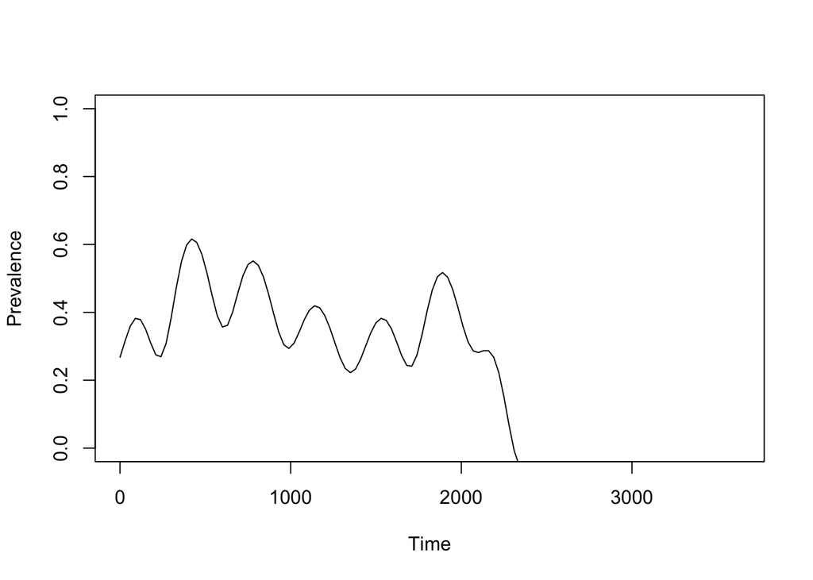

```r
tt <- seq(0, 365*10, by = 30)
mod1 <- xds_solve_cohort(mod1, times=tt)
xds_plot_PR(mod1)
```

If we want to use the model to forecast a few years ahead, we need to add knots. To do this, a gamma distribution with mean 1 is fit to the knots, and we sub-sample from it. The function is called `gam_sample`:

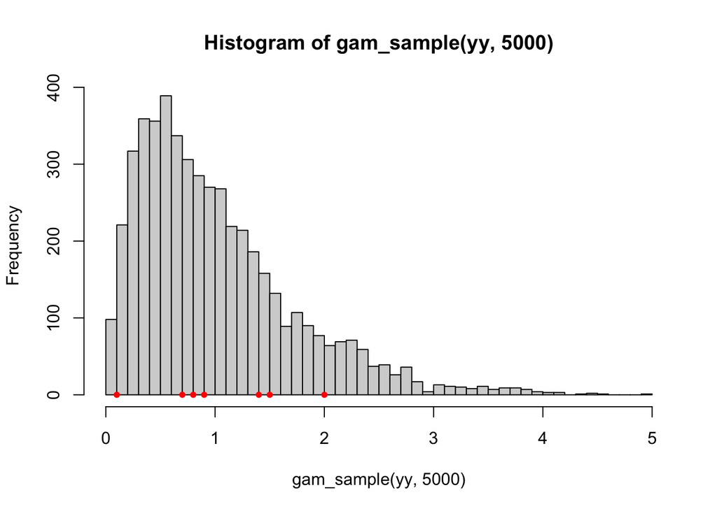

```r
yy <- mod1$EIRpar$trend_par$yy
hist(gam_sample(yy, 5000),55)
points(yy, yy*0, pch = 20, col = "red")
```

The functions `forecast_spline_EIR` and `forecast_spline_Lambda` do this for $N$ years ahead. The forecasting function allows us to exclude the last `x_last` knots when we sub-sample:

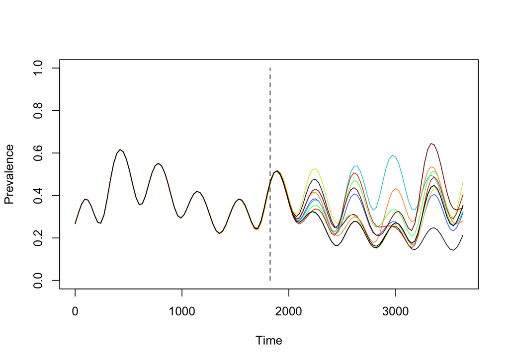

```r
mod1a <- forecast_spline_EIR(mod1, 5, x_last=1)
mod1a <- xds_solve_cohort(mod1a, times=tt)
clrs <- viridis::turbo(8)
xds_plot_PR(mod1a)
for(i in 1:8){
  mod1b <- forecast_spline_EIR(mod1, 5, x_last=1)
  mod1b <- xds_solve_cohort(mod1b, times=tt)
  xds_plot_PR(mod1b, add=TRUE, clrs = clrs[i])
}

xds_plot_PR(mod1a, add=TRUE, clrs = "black")
segments(5*365, 0, 5*365, 1, lty = 2)
```

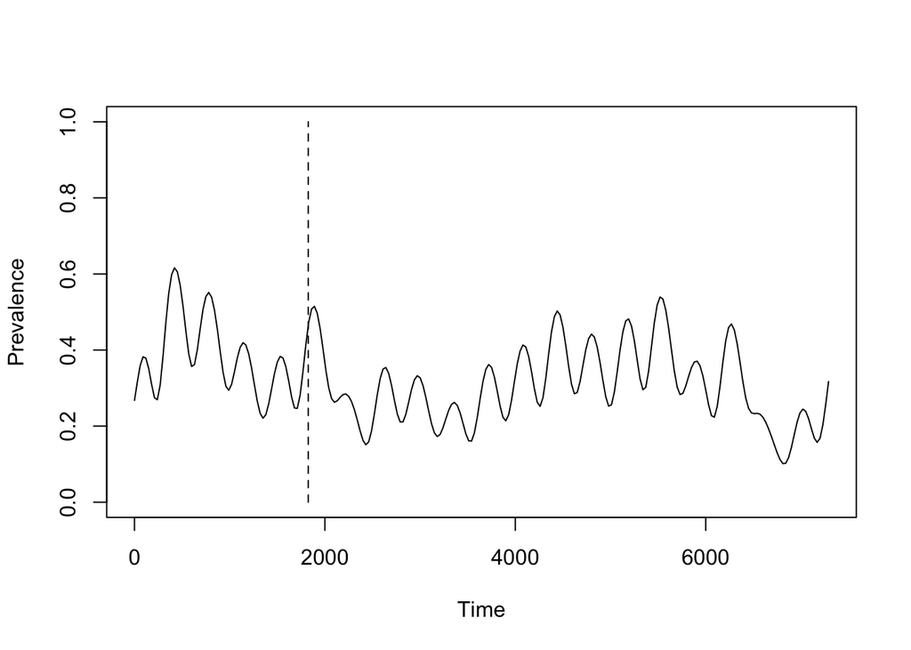

```r
mod1c <- forecast_spline_EIR(mod1, 15, x_last=1)
tt <- seq(0, 365*20, by = 30)
mod1c <- xds_solve_cohort(mod1c, times=tt)
xds_plot_PR(mod1c)
segments(5*365, 0, 5*365, 1, lty = 2)
```

Without the exclusion, the last knot can have a serious effect on our forecast. We should leave it in if it’s real, but if it doesn’t have any real information, it might be best to leave it out.

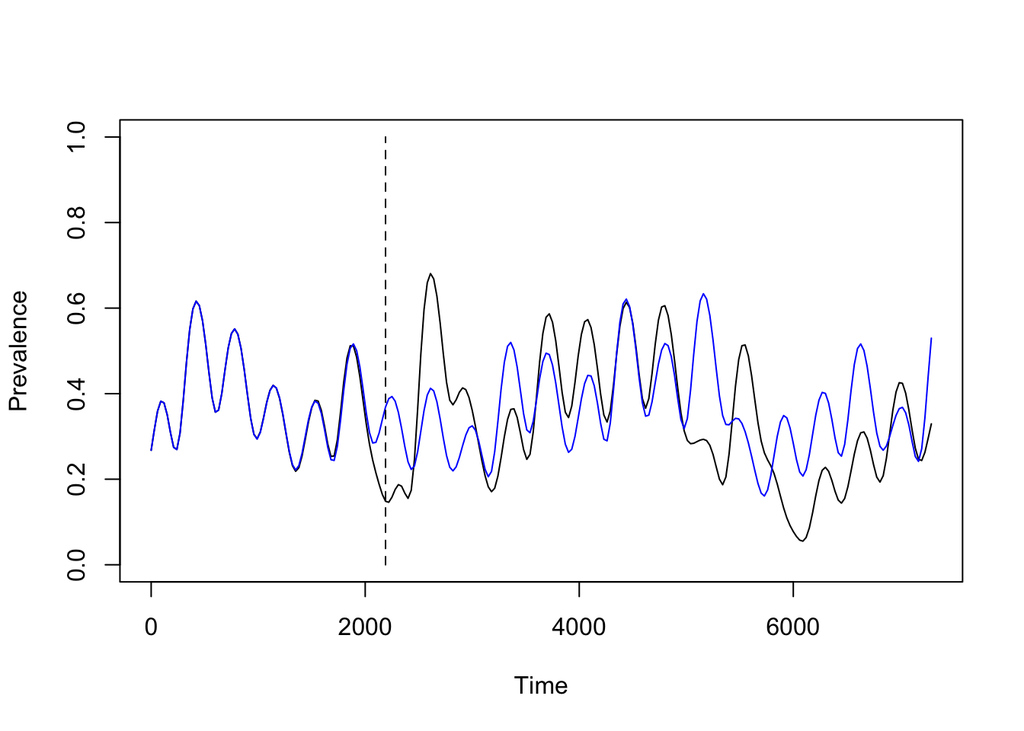

```r
mod1a <- forecast_spline_EIR(mod1, 15)
mod1b <- forecast_spline_EIR(mod1, 15, x_last=1)
mod1a <- xds_solve_cohort(mod1a, times=tt)
mod1b <- xds_solve_cohort(mod1b, times=tt)
xds_plot_PR(mod1a)
xds_plot_PR(mod1b, add=TRUE, clrs = "blue")
segments(6*365, 0, 6*365, 1, lty = 2)
```